# [Rtips] 윈도우 계정 한글일때 문제 해결하기 1탄 임시 폴더 위치 바꾸기

R Rtips temp tempdir

임시 폴더의 위치를 조정해서 윈도우 계정이 한글일때 생기는 문제를 해결합니다.

true  
2019-05-26

[figure not shown]

### 한줄요약

1. `Temp(임시 폴더)`의 위치를 `.Renviron` 파일에 써서 바꾸세요.

[KRSG](https://www.facebook.com/groups/krstudy/)에 [질문글](https://www.facebook.com/groups/krstudy/permalink/1260757344098535/)이 올라와서 아는 내에서 해결책을 공유하고자 합니다.

우선 공유해 주신 에러 화면을 보겠습니다.

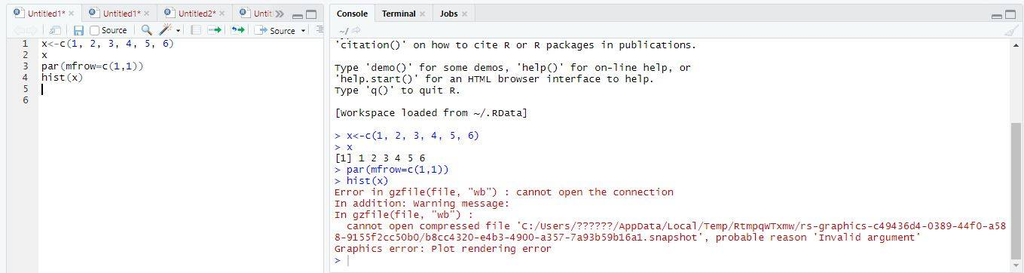

우선 `hist()` 함수를 사용하는데, 에러가 발생한다고 문제를 공유해주셨습니다. 그림을 출력하기 위해서는 그림을 저장하고, 화면에 뿌리는 과정을 진행합니다. 위 과정을 프로그램(rstudio)이 진행해 주기 때문에 과정을 알 필요는 없는데요. 이 때 그림 저장을 임시 폴더에 합니다. 프로그램이 기본으로 사용하는 임시 폴더의 위치는 `tempdir()` 함수로 확인할 수 있습니다. 저의 컴퓨터는 아래 결과를 확인할 수 있었습니다.

```r
tempdir()
```

```
[1] "C:\\Users\\MRCHYP~1\\AppData\\Local\\Temp\\RtmpkNMIVs"
```

이 위치는 윈도우의 사용자 계정 이름(`mrchypark`)의 하위 폴더입니다. 저는 영어로 계정이름을 만들어서 문제 없이 동작하는데요. 질문자의 경우 저 경로에 `??????`로 되어 있는 것으로 봐서 윈도우의 사용자 계정이 한글로 되어 있는 것 같습니다.

그래서 임시 폴더 위치를 변경하는 방법을 소개합니다.

우선 경로에 한글이 없을만한 임시 폴더를 하나 만듭니다. 저는 `C:/`에 바로 만들려고 합니다.

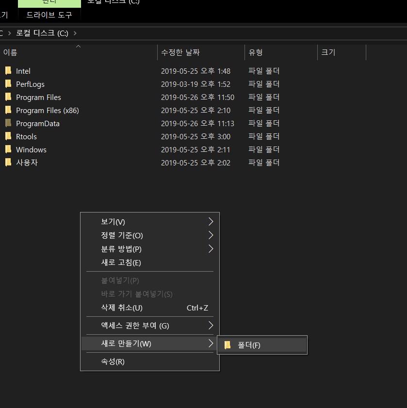

[figure not shown]

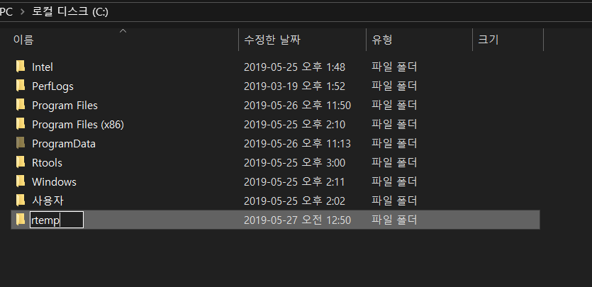

`C:/rtemp` 라는 폴더를 만들었습니다. 이제 `usethis` 패키지를 설치합니다.

```r
install.packages("usethis")
```

`usethis` 패키지에는 `R`의 환경 변수를 관리하는 `.Renvron` 파일을 수정할 수 있게 열어주는 함수를 제공합니다.

```r
library(usethis)
edit_r_environ()
```

그럼 `.Renvron` 파일을 수정할 수 있게 스크립트 창에서 열어줍니다.

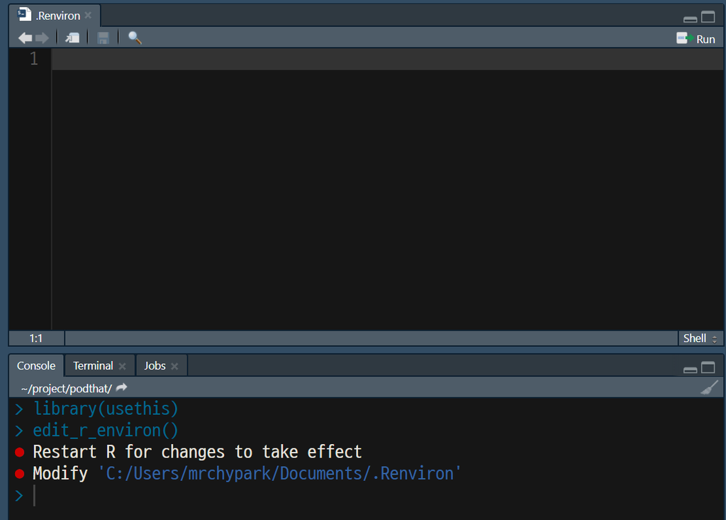

이제 아래 3줄을 `.Renvron` 파일에 저장합니다.

```
TMPDIR=C:/rtemp
TMP=C:/rtemp
TEMP=C:/rtemp
```

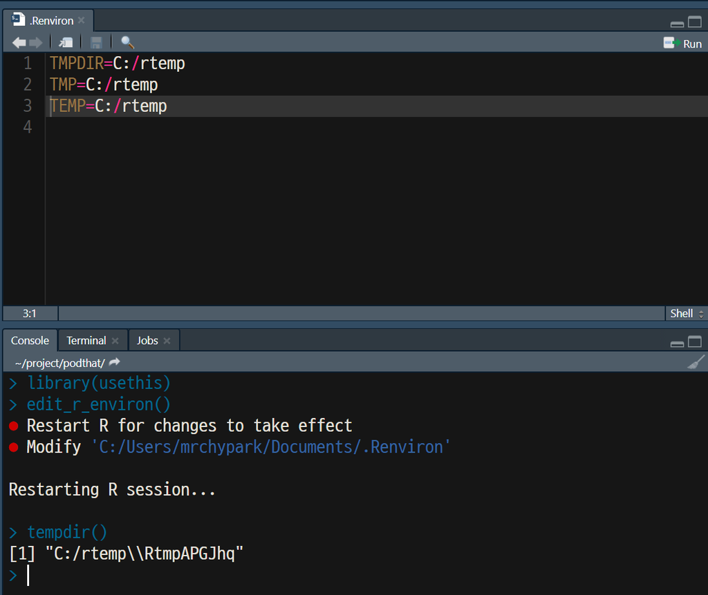

그리고 새션 재시작(`ctrl+shit+F10`)을 한 후 `tempdir()` 함수로 경로가 잘 변경되었는지를 확인합니다.

이제 `hist(iris$Sepal.Length)` 같은 명령어로 동작하는지 확인합니다.

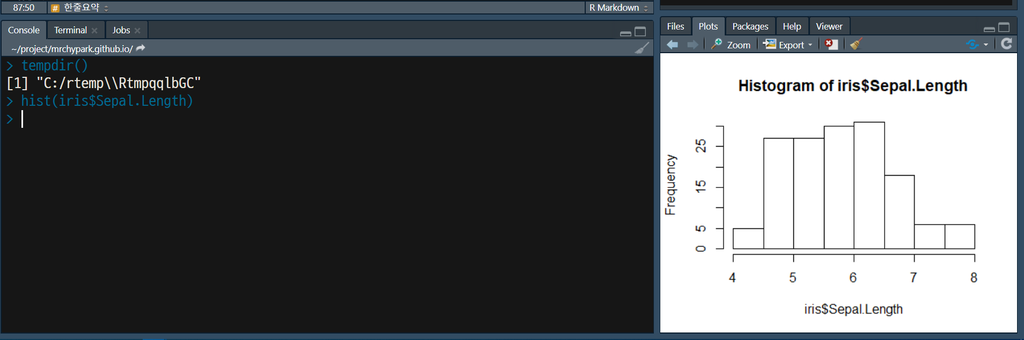

이 방법은 프로그램이 사용하는 임시 폴더의 경로를 바꿈으로써 문제를 해결합니다. 그렇기 때문에 사용자의 계정 폴더를 사용하는 다른 문제에 대해서 해결하는지 알 수 없습니다. 혹시 위 방법으로도 비슷한 에러가 나오는 사례를 알려주시면 감사하겠습니다.

감사합니다.